# Victorian Electricity Retail: Offer Characteristics & Customer Transfers

Arzu Khanna

2025-12-05

## 1 Data Loading & Preparation

This section loads the electricity offer dataset, transfer datasets, and prepares cleaned inputs for further analysis.

### 1.1 Offer Dataset Summary

| Metric | Value |
| --- | --- |
| Total offers loaded | 35,528 |
| Retailers represented | 39 |
| Range of identifier dates | 2022-01-01 → 2025-11-01 |
| Latest identifier date | 2025-11-01 |

### 1.2 Transfer Dataset Summary

| Metric | Value |
| --- | --- |
| Total transfer rows (daily) | 9,005,864 |
| Transfers IN rows | 1,140,421 |
| Transfers OUT rows | 1,140,421 |
| Retailers represented (M57A) | 49 |
| Date range | 2022-01-01 → 2025-10-30 |

## 2 Offer Snapshots, Weekly Aggregation & Lag Features

This section constructs weekly offer snapshots, aggregates transfer data to weekly frequency, and creates lagged feature sets for modelling.

### 2.1 Snapshot Summary

| Metric | Value |
| --- | --- |
| Total weekly snapshot rows | 8,073 |
| Distinct retailers | 39 |
| Date coverage | 2022-01-03 → 2025-12-15 |

### 2.2 Weekly Transfer Summary

| Metric | Value |
| --- | --- |
| Weekly OUT rows | 6,779 |
| Weekly IN rows | 6,385 |
| Retailers represented | 49 |
| Date range | 2021-12-27 → 2025-10-27 |

## 3 Exploratory Data Analysis

This section summarises key trends in offer characteristics and evaluates how these features relate to transfer behaviour across the Victorian electricity market.

### 3.1 Discount structure over time

[interactive chart not shown]

- ‘No discount’ offers dominate at ~ 70 - 80% throughout.
- Guaranteed discounts relatively stable at 12-17% of offers in 2025.
- Conditional discounts declining slightly over time.

### 3.2 Solar and incentive availability over time

[interactive chart not shown]

- Near-universal solar availability (96%+) reflects Victoria’s high solar penetration
- Decline in incentive offers between 2023-2025 (may signal reduced competitive pressure or better / alternative acquisition strategies).

### 3.3 Correlation Analysis - Transfers Out Rate

This matrix summarises linear correlations between offer characteristics and the weekly transfer OUT rate.

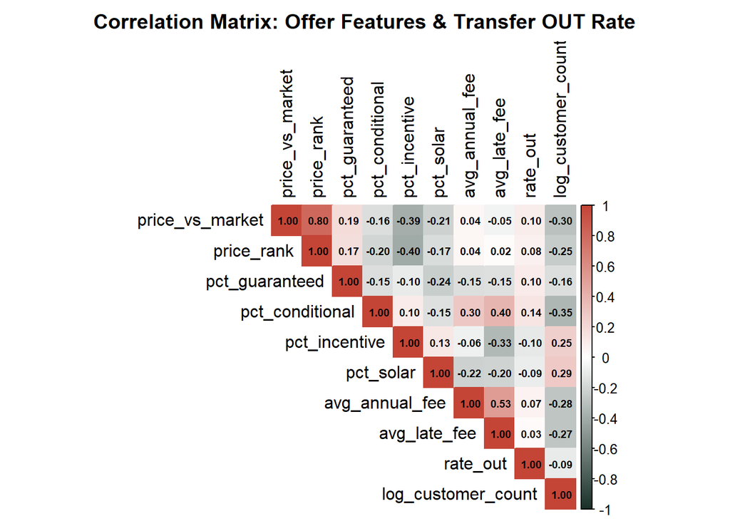

- No strong correlations between transfer rate out and any offer factors.

### 3.4 Correlation Analysis - Transfers In Rate

This matrix summarises correlations between offer features and the weekly transfer IN rate.

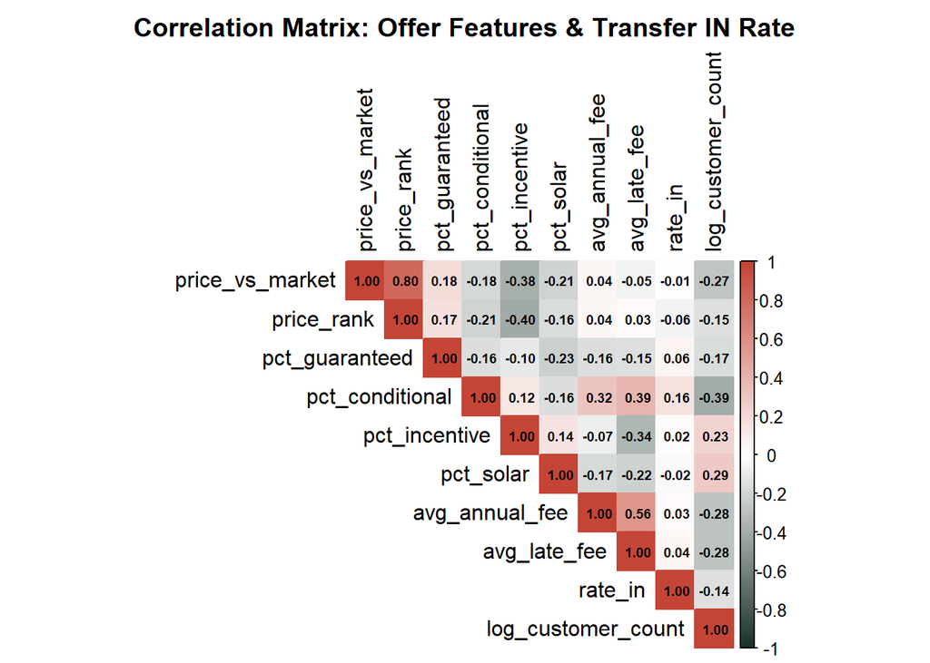

- No strong correlations between transfer rate in and any offer factors.

### 3.5 Transfer OUT: Price vs Transfer Rate (All Retailers)

[interactive chart not shown]

### 3.6 Transfer IN: Price vs Transfer Rate (All Retailers)

[interactive chart not shown]

## 4 Retailer Size Analysis & Individual Retailer Patterns

This section explores how price competitiveness influences transfers across retailer size categories and examines individual retailer behaviour.

### 4.1 Transfer OUT vs Price Position — By Retailer Size

[interactive chart not shown]

- Price has a minimal impact on customer retention for large retailers.
- Large retailers tend to have offers that are around the market median (seen by the dense cluster around Price vs Market (%) = 0).
- Cheaper offers have similar transfer-out rates to expensive offers, suggesting customers leave for reasons other than price.
- Transfer out rates are observed to be the highest when large retailer’s offers are ~130% higher than market median.

[interactive chart not shown]

- Similar to patterns seen for large retailers, however a lot more offers are observed between 200-300% higher than market median.

[interactive chart not shown]

- Small retailer customer are slightly more responsive to higher prices howevere the relationhsip is still very weak.

### 4.2 Transfer In vs Price Position — By Retailer Size

[interactive chart not shown]

### 4.3 Individual Retailer Patterns (Faceted Plots)

Shows if patterns differ by retailer.

**4.3.1 Transfer Out - Faceted by Retailer**

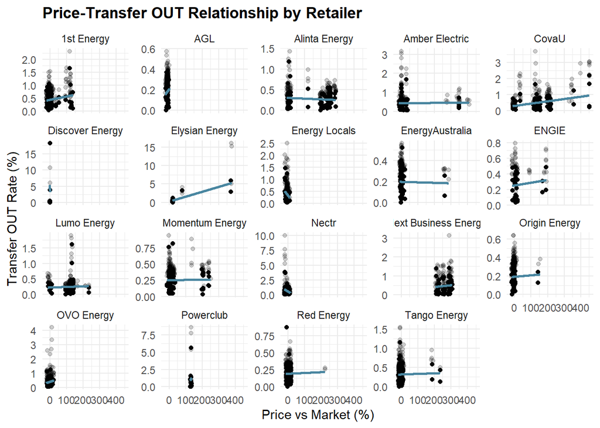

**4.3.2 Transfer In - Faceted by Retailer**

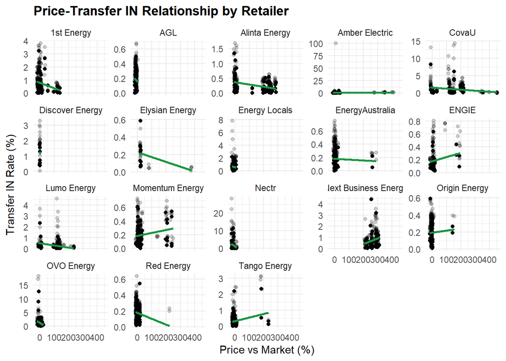

- There is a huge diversity in price-transfer patterns across the different retailers.
- Some retailers have highly price-sensitive customers while others show no relationship (horizontal line).
- Indicates differentiated value proposisions beyond price.

### 4.4 Retailer-Specific Correlation Heatmaps

**4.4.1 Transfer Out - Correlation Heatmap**

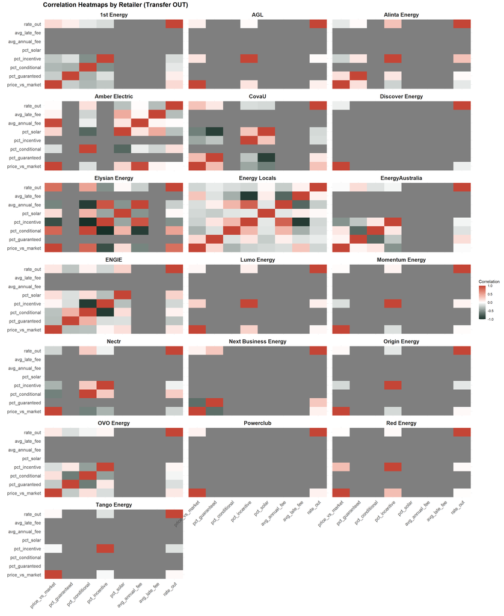

**4.4.2 Transfer In - Correlation Heatmap**

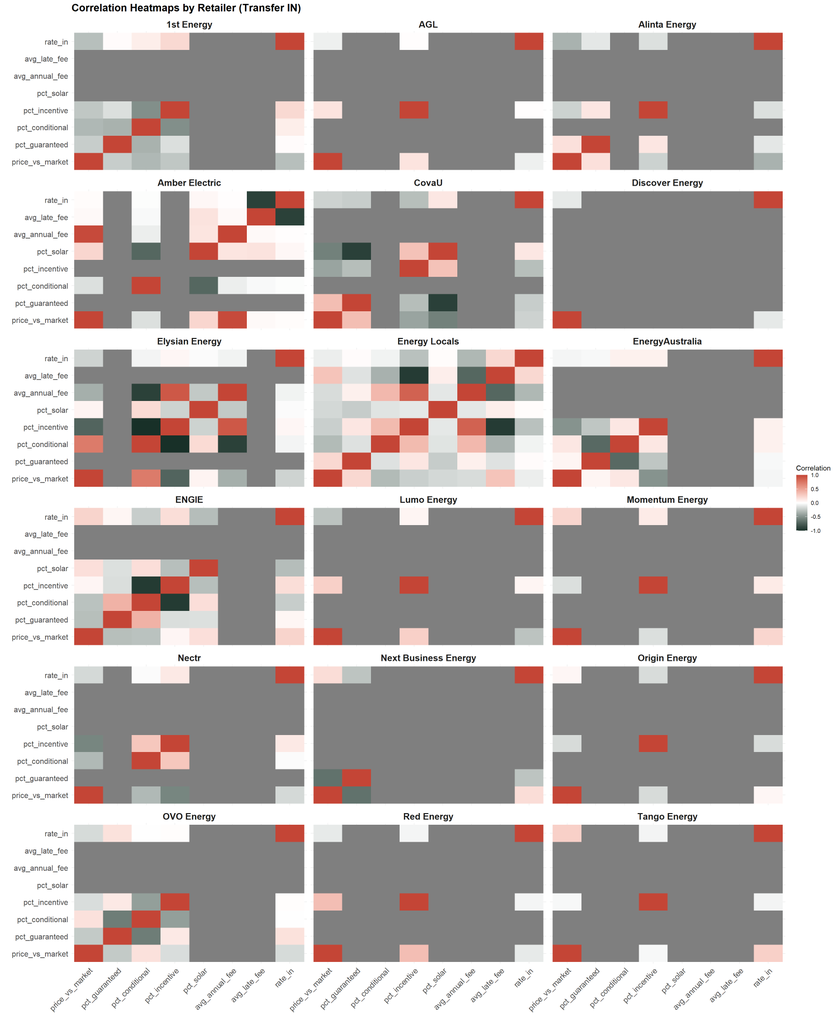

## 5 Price Position Analysis (With Lag Periods)

### 5.1 Segmented Lag Analysis — Transfers Out

Examines how retailer price position (relative to the Victorian market median) affects weekly transfer OUT rates, including lagged effects up to eight weeks.

[interactive chart not shown]

### 5.2 Segmented Lag Analysis — Transfers In

[interactive chart not shown]

## 6 Transfer Out Modelling

This section evaluates how offer characteristics explain weekly transfer OUT rates using linear models, polynomial models, interaction models, and machine-learning methods.

### 6.1 Prepare Dataset for Modelling

### 6.2 Model 1: Linear Regression

```
Call:
lm(formula = rate_out ~ price_vs_market + price_rank + pct_guaranteed +
    pct_conditional + pct_solar + pct_incentive + avg_annual_fee +
    avg_late_fee + log_customers, data = reg_data_out)

Residuals:
   Min     1Q Median     3Q    Max
-0.890 -0.205 -0.032  0.118 17.234

Coefficients:
                 Estimate Std. Error t value Pr(>|t|)
(Intercept)      1.39e+00   8.05e-02   17.23  < 2e-16 ***
price_vs_market  2.49e-04   8.82e-05    2.82   0.0048 **
price_rank      -4.53e-03   1.09e-03   -4.15  3.4e-05 ***
pct_guaranteed   1.49e-03   1.62e-04    9.22  < 2e-16 ***
pct_conditional  3.80e-03   2.72e-04   13.95  < 2e-16 ***
pct_solar        5.89e-04   7.27e-04    0.81   0.4175
pct_incentive   -1.75e-03   1.50e-04  -11.71  < 2e-16 ***
avg_annual_fee   2.10e-04   4.48e-05    4.69  2.8e-06 ***
avg_late_fee    -2.16e-02   1.73e-03  -12.49  < 2e-16 ***
log_customers   -8.92e-02   3.28e-03  -27.18  < 2e-16 ***
---
Signif. codes:  0 '***' 0.001 '**' 0.01 '*' 0.05 '.' 0.1 ' ' 1

Residual standard error: 0.659 on 20626 degrees of freedom
Multiple R-squared:  0.0928,    Adjusted R-squared:  0.0924
F-statistic:  234 on 9 and 20626 DF,  p-value: <2e-16
```

### 6.3 Model 2: Polynomial Regression

```
Call:
lm(formula = rate_out ~ price_vs_market + I(price_vs_market^2) +
    pct_guaranteed + I(pct_guaranteed^2) + pct_conditional +
    I(pct_conditional^2) + pct_incentive + I(pct_incentive^2) +
    avg_annual_fee + I(avg_annual_fee^2) + avg_late_fee + log_customers,
    data = reg_data_out)

Residuals:
   Min     1Q Median     3Q    Max
-1.275 -0.195 -0.031  0.109 17.128

Coefficients:
                      Estimate Std. Error t value Pr(>|t|)
(Intercept)           1.43e+00   4.37e-02   32.87  < 2e-16 ***
price_vs_market      -1.11e-03   1.48e-04   -7.49  7.0e-14 ***
I(price_vs_market^2)  3.54e-06   5.39e-07    6.57  5.2e-11 ***
pct_guaranteed       -1.34e-03   5.83e-04   -2.30    0.021 *
I(pct_guaranteed^2)   3.33e-05   6.70e-06    4.97  6.7e-07 ***
pct_conditional      -7.04e-03   7.46e-04   -9.44  < 2e-16 ***
I(pct_conditional^2)  1.43e-04   8.93e-06   16.00  < 2e-16 ***
pct_incentive        -2.66e-03   5.85e-04   -4.55  5.3e-06 ***
I(pct_incentive^2)    1.06e-05   5.70e-06    1.87    0.062 .
avg_annual_fee       -1.92e-04   1.09e-04   -1.76    0.078 .
I(avg_annual_fee^2)   4.79e-07   8.01e-08    5.98  2.3e-09 ***
avg_late_fee         -1.67e-02   1.84e-03   -9.10  < 2e-16 ***
log_customers        -8.86e-02   3.89e-03  -22.79  < 2e-16 ***
---
Signif. codes:  0 '***' 0.001 '**' 0.01 '*' 0.05 '.' 0.1 ' ' 1

Residual standard error: 0.651 on 20623 degrees of freedom
Multiple R-squared:  0.114, Adjusted R-squared:  0.114
F-statistic:  222 on 12 and 20623 DF,  p-value: <2e-16
```

### 6.4 Model 3: Interaction Effects

```
Call:
lm(formula = rate_out ~ price_vs_market * pct_conditional + price_vs_market *
    avg_annual_fee + pct_guaranteed * pct_incentive + log_customers *
    price_vs_market + price_rank + pct_solar + avg_annual_fee +
    avg_late_fee, data = reg_data_out)

Residuals:
   Min     1Q Median     3Q    Max
-1.571 -0.185 -0.029  0.113 16.937

Coefficients:
                                 Estimate Std. Error t value Pr(>|t|)
(Intercept)                      1.65e+00   9.55e-02   17.29  < 2e-16 ***
price_vs_market                 -1.88e-03   3.33e-04   -5.65  1.6e-08 ***
pct_conditional                  1.75e-03   2.73e-04    6.44  1.2e-10 ***
avg_annual_fee                   9.49e-05   6.75e-05    1.41  0.15945
pct_guaranteed                   4.20e-03   2.60e-04   16.14  < 2e-16 ***
pct_incentive                   -5.96e-04   1.59e-04   -3.76  0.00017 ***
log_customers                   -9.91e-02   3.67e-03  -27.03  < 2e-16 ***
price_rank                      -1.23e-03   1.11e-03   -1.12  0.26462
pct_solar                       -1.59e-03   7.73e-04   -2.06  0.03942 *
avg_late_fee                    -1.72e-02   1.72e-03  -10.01  < 2e-16 ***
price_vs_market:pct_conditional  1.04e-04   2.91e-06   35.82  < 2e-16 ***
price_vs_market:avg_annual_fee  -1.21e-06   2.44e-07   -4.96  7.0e-07 ***
pct_guaranteed:pct_incentive    -5.77e-05   4.24e-06  -13.61  < 2e-16 ***
price_vs_market:log_customers    1.36e-04   3.16e-05    4.31  1.6e-05 ***
---
Signif. codes:  0 '***' 0.001 '**' 0.01 '*' 0.05 '.' 0.1 ' ' 1

Residual standard error: 0.638 on 20622 degrees of freedom
Multiple R-squared:  0.15,  Adjusted R-squared:  0.15
F-statistic:  281 on 13 and 20622 DF,  p-value: <2e-16
```

### 6.5 Model 4: Random Forest

```
Call:
 randomForest(formula = rate_out ~ ., data = rf_data_out, ntree = 500,      importance = TRUE, mtry = 3)
               Type of random forest: regression
                     Number of trees: 500
No. of variables tried at each split: 3

          Mean of squared residuals: 0.04879
                    % Var explained: 89.81
```

[interactive chart not shown]

### 6.6 Model 5: XGBoost

```
##### xgb.Booster
raw: 313.4 Kb
call:
  xgb.train(params = params, data = dtrain, nrounds = nrounds,
    watchlist = watchlist, verbose = verbose, print_every_n = print_every_n,
    early_stopping_rounds = early_stopping_rounds, maximize = maximize,
    save_period = save_period, save_name = save_name, xgb_model = xgb_model,
    callbacks = callbacks, max_depth = 6, eta = 0.1, objective = "reg:squarederror")
params (as set within xgb.train):
  max_depth = "6", eta = "0.1", objective = "reg:squarederror", validate_parameters = "TRUE"
xgb.attributes:
  niter
callbacks:
  cb.evaluation.log()
# of features: 9
niter: 100
nfeatures : 9
evaluation_log:
  iter train_rmse
 <num>      <num>
     1     0.6518
     2     0.6051
   ---        ---
    99     0.1847
   100     0.1840
```

[interactive chart not shown]

### 6.7 Model Comparison

Model Comparison – Transfer OUT

| Model | R_Squared | Adj_R_Squared |
| --- | --- | --- |
| XGBoost | 0.9292 | NA |
| Random Forest | 0.9223 | NA |
| Interaction Model | 0.1503 | 0.1497 |
| Polynomial Regression | 0.1144 | 0.1139 |
| Linear Regression | 0.0928 | 0.0924 |

## 7 Transfer In Modelling

### 7.1 Prepare Dataset for Modelling

### 7.2 Model 1: Linear Regression

```
Call:
lm(formula = rate_in ~ price_vs_market + price_rank + pct_guaranteed +
    pct_conditional + pct_solar + pct_incentive + avg_annual_fee +
    avg_late_fee + log_customers, data = reg_data_in)

Residuals:
   Min     1Q Median     3Q    Max
 -1.77  -0.35  -0.05   0.16  96.76

Coefficients:
                 Estimate Std. Error t value Pr(>|t|)
(Intercept)      2.95e+00   1.51e-01   19.52  < 2e-16 ***
price_vs_market  1.28e-04   1.64e-04    0.78    0.435
price_rank      -2.00e-02   2.00e-03  -10.04  < 2e-16 ***
pct_guaranteed   7.58e-04   2.97e-04    2.56    0.011 *
pct_conditional -1.33e-04   5.09e-04   -0.26    0.794
pct_solar        1.21e-02   1.36e-03    8.90  < 2e-16 ***
pct_incentive    2.03e-03   2.78e-04    7.31  2.7e-13 ***
avg_annual_fee  -7.36e-04   8.74e-05   -8.42  < 2e-16 ***
avg_late_fee     2.96e-03   3.22e-03    0.92    0.359
log_customers   -3.08e-01   6.21e-03  -49.65  < 2e-16 ***
---
Signif. codes:  0 '***' 0.001 '**' 0.01 '*' 0.05 '.' 0.1 ' ' 1

Residual standard error: 1.19 on 20134 degrees of freedom
Multiple R-squared:  0.146, Adjusted R-squared:  0.146
F-statistic:  384 on 9 and 20134 DF,  p-value: <2e-16
```

### 7.3 Model 2: Polynomial Regression

```
Call:
lm(formula = rate_in ~ price_vs_market + I(price_vs_market^2) +
    pct_guaranteed + I(pct_guaranteed^2) + pct_conditional +
    I(pct_conditional^2) + pct_incentive + I(pct_incentive^2) +
    avg_annual_fee + I(avg_annual_fee^2) + avg_late_fee + log_customers,
    data = reg_data_in)

Residuals:
   Min     1Q Median     3Q    Max
 -2.42  -0.33  -0.08   0.19  96.78

Coefficients:
                      Estimate Std. Error t value Pr(>|t|)
(Intercept)           4.57e+00   8.35e-02   54.78  < 2e-16 ***
price_vs_market      -1.08e-03   2.79e-04   -3.87  0.00011 ***
I(price_vs_market^2) -2.84e-06   1.03e-06   -2.75  0.00603 **
pct_guaranteed        1.03e-03   1.07e-03    0.96  0.33495
I(pct_guaranteed^2)  -2.42e-05   1.23e-05   -1.97  0.04939 *
pct_conditional       6.73e-03   1.36e-03    4.96  7.2e-07 ***
I(pct_conditional^2) -9.18e-05   1.63e-05   -5.62  1.9e-08 ***
pct_incentive         5.21e-03   1.08e-03    4.84  1.3e-06 ***
I(pct_incentive^2)   -2.14e-05   1.05e-05   -2.05  0.04052 *
avg_annual_fee       -4.42e-03   2.00e-04  -22.05  < 2e-16 ***
I(avg_annual_fee^2)   3.14e-06   1.54e-07   20.45  < 2e-16 ***
avg_late_fee          2.11e-02   3.39e-03    6.22  5.0e-10 ***
log_customers        -3.64e-01   7.39e-03  -49.21  < 2e-16 ***
---
Signif. codes:  0 '***' 0.001 '**' 0.01 '*' 0.05 '.' 0.1 ' ' 1

Residual standard error: 1.18 on 20131 degrees of freedom
Multiple R-squared:  0.157, Adjusted R-squared:  0.157
F-statistic:  313 on 12 and 20131 DF,  p-value: <2e-16
```

### 7.4 Model 3: Interaction Effects

```
Call:
lm(formula = rate_in ~ price_vs_market * pct_conditional + price_vs_market *
    avg_annual_fee + pct_guaranteed * pct_incentive + log_customers *
    price_vs_market + price_rank + pct_solar + avg_annual_fee +
    avg_late_fee, data = reg_data_in)

Residuals:
   Min     1Q Median     3Q    Max
 -3.06  -0.34  -0.06   0.19  96.29

Coefficients:
                                 Estimate Std. Error t value Pr(>|t|)
(Intercept)                      4.95e+00   1.81e-01   27.34  < 2e-16 ***
price_vs_market                 -4.95e-03   6.21e-04   -7.96  1.8e-15 ***
pct_conditional                 -7.00e-04   5.11e-04   -1.37   0.1713
avg_annual_fee                  -2.63e-03   1.38e-04  -19.03  < 2e-16 ***
pct_guaranteed                  -4.45e-03   4.93e-04   -9.02  < 2e-16 ***
pct_incentive                    8.46e-04   3.03e-04    2.79   0.0052 **
log_customers                   -3.82e-01   7.06e-03  -54.07  < 2e-16 ***
price_rank                      -2.15e-02   2.06e-03  -10.44  < 2e-16 ***
pct_solar                        1.97e-03   1.47e-03    1.34   0.1804
avg_late_fee                     1.14e-03   3.30e-03    0.35   0.7298
price_vs_market:pct_conditional  6.06e-05   1.21e-05    5.01  5.5e-07 ***
price_vs_market:avg_annual_fee   6.98e-06   4.93e-07   14.16  < 2e-16 ***
pct_guaranteed:pct_incentive     9.52e-05   7.96e-06   11.96  < 2e-16 ***
price_vs_market:log_customers    4.44e-04   5.91e-05    7.51  6.0e-14 ***
---
Signif. codes:  0 '***' 0.001 '**' 0.01 '*' 0.05 '.' 0.1 ' ' 1

Residual standard error: 1.18 on 20130 degrees of freedom
Multiple R-squared:  0.168, Adjusted R-squared:  0.167
F-statistic:  313 on 13 and 20130 DF,  p-value: <2e-16
```

### 7.5 Model 4: Random Forest

```
Call:
 randomForest(formula = rate_in ~ ., data = rf_data_in, ntree = 500,      importance = TRUE, mtry = 3)
               Type of random forest: regression
                     Number of trees: 500
No. of variables tried at each split: 3

          Mean of squared residuals: 0.6426
                    % Var explained: 61.39
```

[interactive chart not shown]

### 7.6 Model 5: XGBoost

```
##### xgb.Booster
raw: 251.5 Kb
call:
  xgb.train(params = params, data = dtrain, nrounds = nrounds,
    watchlist = watchlist, verbose = verbose, print_every_n = print_every_n,
    early_stopping_rounds = early_stopping_rounds, maximize = maximize,
    save_period = save_period, save_name = save_name, xgb_model = xgb_model,
    callbacks = callbacks, max_depth = 6, eta = 0.1, objective = "reg:squarederror")
params (as set within xgb.train):
  max_depth = "6", eta = "0.1", objective = "reg:squarederror", validate_parameters = "TRUE"
xgb.attributes:
  niter
callbacks:
  cb.evaluation.log()
# of features: 9
niter: 100
nfeatures : 9
evaluation_log:
  iter train_rmse
 <num>      <num>
     1     1.2298
     2     1.1771
   ---        ---
    99     0.3621
   100     0.3607
```

[interactive chart not shown]

### 7.7 Model Comparison (Transfer IN)

Model Comparison – Transfer IN

| Model | R_Squared | Adj_R_Squared |
| --- | --- | --- |
| XGBoost | 0.9218 | NA |
| Random Forest | 0.8853 | NA |
| Interaction Model | 0.1679 | 0.1674 |
| Polynomial Regression | 0.1572 | 0.1567 |
| Linear Regression | 0.1465 | 0.1461 |

## 8 Comparison: OUT vs IN Drivers

### 8.1 Coefficient Comparison Table

Comparison of Predictors Affecting OUT vs IN Transfers

| Predictor | Estimate_OUT | Estimate_IN | Interpretation |
| --- | --- | --- | --- |
| log_customers | -0.0892 | -0.3084 | Same direction (both) |
| avg_late_fee | -0.0216 | 0.0030 | Only affects OUT |
| price_rank | -0.0045 | -0.0200 | Same direction (both) |
| pct_conditional | 0.0038 | -0.0001 | Only affects OUT |
| pct_incentive | -0.0018 | 0.0020 | Opposite effects ⚠️ |
| pct_guaranteed | 0.0015 | 0.0008 | Same direction (both) |
| pct_solar | 0.0006 | 0.0121 | Only affects IN |
| price_vs_market | 0.0002 | 0.0001 | Only affects OUT |
| avg_annual_fee | 0.0002 | -0.0007 | Opposite effects ⚠️ |